# Classification. Logistic Regression

```python
import pandas as pd
import matplotlib.pyplot as plt
import numpy as np
```

# . reading our dataset from the corresponding txt file: score_first_exam, score_second_exam, has_admitted

```python
learning_set_path = "./ex2data1.txt"
learning_data = pd.read_csv(learning_set_path, header=None, names=['Exam 1', 'Exam 2', 'Admitted'])
print(learning_data.head())
```

```
      Exam 1     Exam 2  Admitted
0  34.623660  78.024693         0
1  30.286711  43.894998         0
2  35.847409  72.902198         0
3  60.182599  86.308552         1
4  79.032736  75.344376         1
```

Scatter plotting our dataset helps to identify certain patterns

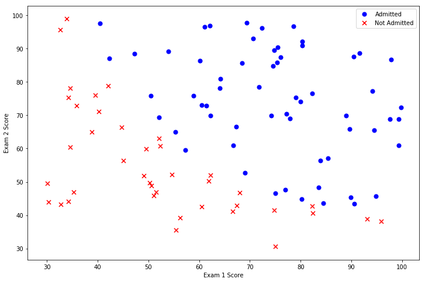

```python
positive = learning_data[learning_data['Admitted'].isin([1])]
negative = learning_data[learning_data['Admitted'].isin([0])]
fig, ax = plt.subplots(figsize=(12,8))
ax.scatter(positive['Exam 1'], positive['Exam 2'], s=50, c='b', marker='o', label='Admitted')
ax.scatter(negative['Exam 1'], negative['Exam 2'], s=50, c='r', marker='x', label='Not Admitted')
ax.legend()
ax.set_xlabel('Exam 1 Score')
ax.set_ylabel('Exam 2 Score')
plt.show()
```

Notice that if the student was bad on both exames than he didn't passed and in opposite if he was good or excellent then he is passed

Now we will implement logistic regression so we can train a classification model to find the optimal decision boundary and make class predictions. For this simple approach our boundary is a linecurve.

```python
def sigmoid(z):
    # ====================== YOUR CODE HERE ======================
    # Instructions: Compute the sigmoid of each value of z (z can be a matrix,
    #               vector or scalar).
    """
    return: computed sigmoid of z (in our case array)
    """
    return 1 / (1 + np.exp(-z))
```

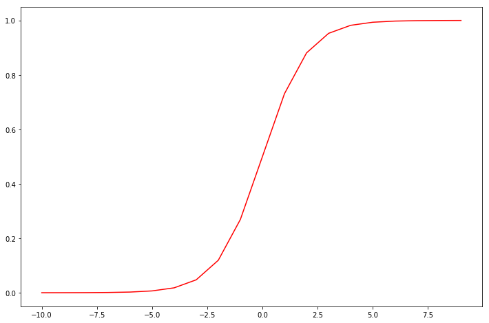

```python
nums = np.arange(-10, 10, step=1)
fig, ax = plt.subplots(figsize=(12,8))
ax.plot(nums, sigmoid(nums), 'r')
plt.show()
```

let's add constant feature 'ones' to our learning dataset in order to get benefit from matrixes and operations on them

```python
learning_data.insert(0, 'Ones', 1)
print learning_data.head()
```

[output not shown]

split features and expected output into separate datasets

```python
cols = learning_data.shape[1]
X = learning_data.iloc[:,0:cols-1]
y = learning_data.iloc[:,cols-1:cols]
print X.head()
print y.head()
```

```
   Ones     Exam 1     Exam 2
0     1  34.623660  78.024693
1     1  30.286711  43.894998
2     1  35.847409  72.902198
3     1  60.182599  86.308552
4     1  79.032736  75.344376
   Admitted
0         0
1         0
2         0
3         1
4         1
```

```python
# convert to numpy array in order to pass to cost function
X = np.array(X.values)
y = np.array(y.values)
```

## Now implement cost function.

NOTE: By the way originally quality of classification function is measure as percentage of True results. However this function is not easy to optimize, so we need it to be a smooth and continuous in order to use gradient descent method. So instead, we define a mapping using functional. We want to reflect those values on a smooth function and one such function that can map the original values between 0 and 1 is sigmoid. Sigmoid is applied on top of our function and now the values are real between 0 and 1 and it is continuous and smooth which means that we can differentiate it and apply gradient methods.

```python
def cost(theta, X, y):
    theta = np.matrix(theta)
    X = np.matrix(X)
    y = np.matrix(y)
    l = len(X)
    # NOTE: see equation in the task for cost function of sigmoid
    first_term = np.multiply(-y, np.log(sigmoid(X * theta.T)))
    second_term = np.multiply((1 - y), np.log(1 - sigmoid(X * theta.T)))
    return np.sum(first_term - second_term) / l
```

Initialize theta (vector of weights for our classification model)

```python
theta = np.zeros(3)   # since we have only three features (exam_1_score, exam_2_score, constant 1s)
```

```python
print('\n\n Cost at zero initialization: {0:.2f}'.format(cost(theta, X, y)))
```

```
 Cost at zero initialization: 0.69
```

## Gradient descent optimization

At each training iteration we update the parameters in a way that’s guaranteed to move them in a direction that reduces the training error (i.e. the “cost”). Mention it again, we can do this because the cost function is differentiable.

```python
def gradient(theta, X, y):
    # NOTE: Refer to task description for equation of sigmoid gradient function
    # convert to matrixes to get benefit from matrix operations in linear algebra
    theta = np.matrix(theta)
    X = np.matrix(X)
    y = np.matrix(y)

    parameters = int(theta.ravel().shape[1])   # number of parameters
    grad = np.zeros(parameters)   # initialize gradient vector
    error_value = sigmoid(X * theta.T) - y

    for i in range(parameters):
        term = np.multiply(error_value, X[:,i])   # multiply value of ith feature by error (see equation of sigmoid gradient)
        grad[i] = np.sum(term) / len(X)   # calculate gradient vector of coordinate at base (x_i)
    return grad
```

Let's use scipy API in order to optimize our theta parameters

```python
import scipy.optimize as opt
result = opt.fmin_tnc(func=cost, x0=theta, fprime=gradient, args=(X, y))
print "weight vector=", result[0]
cost(result[0], X, y)
```

```
weight vector= [-25.16131863   0.20623159   0.20147149]
```

```
0.20349770158947458
```

Cost is near with 0 which is really good sign

Let's finally write prediction function with a probability threshold greater than or equal 0.5

```python
def predict(theta, X):
    probability = sigmoid(X * theta.T)
    return [1 if x >= 0.5 else 0 for x in probability]
```

```python
theta_opt = np.matrix(result[0])
predictions = predict(theta_opt, X)
# estimate accuracy
correct = [
    1 if ((y == pred_y == 1) or (y == pred_y == 0)) else 0
    for (pred_y, y) in zip(predictions, y)]
accuracy = (sum(map(int, correct)) % len(correct))
print 'accuracy = {0}%'.format(accuracy)
```

```
accuracy = 89%
```

89% accuracy is not bad